# Extended vignette for **EEAaq: Handle Air Quality Data from the European Environment Agency Data Portal**

Paolo Maranzano, University of Milano-Bicocca, Italy, paolo.maranzano@unimib.it

Riccardo Borgoni, University of Milano-Bicocca, Italy, riccardo.borgoni@unimib.it

Agostino Tassan Mazzocco, University of Milano-Bicocca, Italy

Samir Doghmi, University of Milano-Bicocca, Italy

24 marzo 2025

The **EEAaq package** allows users to retrieve air quality data for a user-defined vector of stations ID (to be pre-filtered by the user before the query), pollutants, and time periods in a single request. Queries are submitted to EEA air quality data flow as lists, which enables flexibility in specifying combinations of parameters.

```r
library(EEAaq)
library(tidyverse)
library(sf)
```

# EEAaq_get_data

Below we demonstrate the use of query by using different combinations of user-defined arguments.

### Retrieve stations currently active in the municipality of Milano (Italy) measuring NO$_2$ concentrations

```r
IDstats <- EEAaq_get_stations(byStation = FALSE, complete = TRUE)
IDstats_MI <- IDstats %>%
  filter(Country %in% c("Italy"),          # Country
         LAU_NAME %in% c("Milano"),        # City/municipality
         AirPollutant %in% c("NO2"),       # Pollutant of interest
         is.na(OperationalActivityEnd))    # Currently operating
```

```r
data_lau <- EEAaq::EEAaq_get_data(
  IDstations = unique(IDstats_MI$AirQualityStationEoICode),   # List of stations
  pollutants = "PM10",      # Pollutant
  from = "2022-01-01",      # Start date
  to = "2023-12-31",        # End date
  verbose = FALSE           # Print detailed progress
)
```

```r
# Preview the first few rows of the dataset
head(data_lau)
```

| AirQualityStationEoICode | AirQualityStationName | DatetimeBegin | DatetimeEnd | AveragingTime | PM10 |
| --- | --- | --- | --- | --- | --- |
| IT0477A | MILANO - V.LE MARCHE | 2022-01-01 01:00:00 | 2022-01-02 01:00:00 | day | 135.19771 |
| IT0477A | MILANO - V.LE MARCHE | 2022-01-02 01:00:00 | 2022-01-03 01:00:00 | day | 77.60741 |
| IT0477A | MILANO - V.LE MARCHE | 2022-01-03 01:00:00 | 2022-01-04 01:00:00 | day | 44.88311 |
| IT0477A | MILANO - V.LE MARCHE | 2022-01-04 01:00:00 | 2022-01-05 01:00:00 | day | 51.54195 |
| IT0477A | MILANO - V.LE MARCHE | 2022-01-05 01:00:00 | 2022-01-06 01:00:00 | day | 23.63635 |
| IT0477A | MILANO - V.LE MARCHE | 2022-01-06 01:00:00 | 2022-01-07 01:00:00 | day | 21.04598 |

### Retrieve PM$_{10}$ and NO$_2$ data for user-defined a specific macroregion (see the Eurostat classification NUTS-1)

```r
# Identify the names of the areas from which to download the data
zones <- c("Région de Bruxelles-Capitale/Brussels Hoofdstedelijk Gewest",
           "Vlaams Gewest",
           "West-Nederland",
           "Zuid-Nederland")

IDstats_Benelux <- IDstats %>%
  filter(NUTS1 %in% zones,                   # Regions of interest
    AirPollutant %in% c("NO2","PM10"),   # Pollutants of interest
    is.na(OperationalActivityEnd)        # Currently operating
  )

# Download the corresponding data
data <- EEAaq_get_data(
  IDstations = unique(IDstats_Benelux$AirQualityStationEoICode),   # List of stations
  pollutants = c("NO2", "PM10"),     # Pollutant
  from = "2023-01-01",               # Start date
  to = "2023-12-31",                 # End date
  verbose = FALSE                    # Print detailed progress
)
```

```r
unique(data$AirQualityStationEoICode)
```

```
##   [1] "BELAL02" "BELAL03" "BELAL04" "BELAL05" "BELAT44" "BELAT83" "BELEG05"
##   [8] "BELHB23" "BELHH08" "BELLD02" "BELMN01" "BELOB01" "BELRL01" "BELSA04"
##  [15] "BELSA08" "BELSZ05" "BETAL09" "BETAL10" "BETB001" "BETB004" "BETB006"
##  [22] "BETB008" "BETB011" "BETBUL1" "BETCHA1" "BETDU07" "BETE007" "BETE008"
##  [29] "BETE009" "BETE013" "BETE703" "BETE704" "BETE714" "BETE715" "BETE716"
##  [36] "BETE814" "BETGK11" "BETM705" "BETM802" "BETMEU1" "BETN012" "BETN016"
##  [43] "BETN027" "BETN029" "BETN035" "BETN040" "BETN043" "BETN047" "BETN052"
##  [50] "BETN054" "BETR001" "BETR002" "BETR012" "BETR020" "BETR701" "BETR702"
##  [57] "BETR710" "BETR731" "BETR740" "BETR750" "BETR801" "BETR802" "BETR803"
##  [64] "BETR804" "BETR805" "BETR806" "BETR817" "BETR818" "BETR822" "BETR823"
##  [71] "BETR830" "BETR831" "BETR834" "BETR842" "BETR891" "BETR892" "BETR897"
##  [78] "BETREG1" "BETVBX1" "BETVBX2" "BETVBX3" "BETZD01" "BETZD08" "NL00107"
##  [85] "NL00131" "NL00133" "NL00136" "NL00138" "NL00235" "NL00236" "NL00237"
##  [92] "NL00240" "NL00241" "NL00246" "NL00247" "NL00301" "NL00318" "NL00538"
##  [99] "NL00546" "NL00551" "NL00553" "NL00556" "NL00570" "NL00572" "NL00573"
## [106] "NL00701" "NL00704" "NL01913" "NL49557"
```

```r
knitr::kable(head(data,20))
```

| AirQualityStationEoICode | AirQualityStationName | DatetimeBegin | DatetimeEnd | AveragingTime | PM10 | NO2 |
| --- | --- | --- | --- | --- | --- | --- |
| BELAL02 | 40AL02 - BEVEREN | 2023-01-01 01:00:00 | 2023-01-01 02:00:00 | hour | NaN | NA |
| BELAL02 | 40AL02 - BEVEREN | 2023-01-01 02:00:00 | 2023-01-01 03:00:00 | hour | NaN | NA |
| BELAL02 | 40AL02 - BEVEREN | 2023-01-01 03:00:00 | 2023-01-01 04:00:00 | hour | NaN | NA |
| BELAL02 | 40AL02 - BEVEREN | 2023-01-01 04:00:00 | 2023-01-01 05:00:00 | hour | NaN | NA |
| BELAL02 | 40AL02 - BEVEREN | 2023-01-01 05:00:00 | 2023-01-01 06:00:00 | hour | NaN | NA |
| BELAL02 | 40AL02 - BEVEREN | 2023-01-01 06:00:00 | 2023-01-01 07:00:00 | hour | NaN | NA |
| BELAL02 | 40AL02 - BEVEREN | 2023-01-01 07:00:00 | 2023-01-01 08:00:00 | hour | NaN | NA |
| BELAL02 | 40AL02 - BEVEREN | 2023-01-01 08:00:00 | 2023-01-01 09:00:00 | hour | NaN | NA |
| BELAL02 | 40AL02 - BEVEREN | 2023-01-01 09:00:00 | 2023-01-01 10:00:00 | hour | NaN | NA |
| BELAL02 | 40AL02 - BEVEREN | 2023-01-01 10:00:00 | 2023-01-01 11:00:00 | hour | NaN | NA |
| BELAL02 | 40AL02 - BEVEREN | 2023-01-01 11:00:00 | 2023-01-01 12:00:00 | hour | NaN | NA |
| BELAL02 | 40AL02 - BEVEREN | 2023-01-01 12:00:00 | 2023-01-01 13:00:00 | hour | NaN | NA |
| BELAL02 | 40AL02 - BEVEREN | 2023-01-01 13:00:00 | 2023-01-01 14:00:00 | hour | NaN | NA |
| BELAL02 | 40AL02 - BEVEREN | 2023-01-01 14:00:00 | 2023-01-01 15:00:00 | hour | NaN | NA |
| BELAL02 | 40AL02 - BEVEREN | 2023-01-01 15:00:00 | 2023-01-01 16:00:00 | hour | NaN | NA |
| BELAL02 | 40AL02 - BEVEREN | 2023-01-01 16:00:00 | 2023-01-01 17:00:00 | hour | NaN | NA |
| BELAL02 | 40AL02 - BEVEREN | 2023-01-01 17:00:00 | 2023-01-01 18:00:00 | hour | NaN | NA |
| BELAL02 | 40AL02 - BEVEREN | 2023-01-01 18:00:00 | 2023-01-01 19:00:00 | hour | NaN | NA |
| BELAL02 | 40AL02 - BEVEREN | 2023-01-01 19:00:00 | 2023-01-01 20:00:00 | hour | NaN | NA |
| BELAL02 | 40AL02 - BEVEREN | 2023-01-01 20:00:00 | 2023-01-01 21:00:00 | hour | NaN | NA |

**Note 1**: Notice that, if the selected stations have a valid value for *CITY_NAME* (i.e., not NULL in the dataset), the function will enquire the EEA database directly with improved-speed filters (in this case, the download require a short time). If no valid CITY_NAME is associated with the stations (i.e., it is NULL for at least one station), the function attempts to retrieve all available data for the entire country and subsequently filter for the specified stations (in this case, the download can require a longer time).

**Note 2**: For very small towns or certain countries such as Turkey or Albania, data may not currently be available in the dataset.This limitation reflects the data unavailability at the [EEA Air Quality Viewer](https://discomap.eea.europa.eu/App/AQViewer/index.html?fqn=Airquality_Dissem.b2g.AirQualityStatistics).

# EEAaq map stations

`EEAaq_map_stations` generates a static or dynamic map of user-defined monitoring stations. The function accepts as input either an object of the `EEAaq_df` class (default output of the `EEAaq_get_data` function), or all other parameters specifying the area and the pollutants.

### Map the stations using as `EEAaq_df` object, the dataset concerning NO$_2$ and PM$_{10}$ in Belgium and The Netherlands

```r
EEAaq_map_stations(
  data = data,
  NUTS_extborder = "NUTS2",
  NUTS_intborder =  "NUTS3",
  color = FALSE,
  dynamic = FALSE
)
```

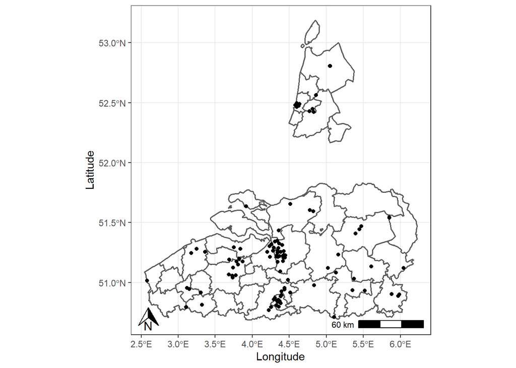

**Note**: Using the parameter `NUTS_intborder = "NUTS3"` and `NUTS_extborder = "NUTS2"`, the map is generated with internal boundaries corresponding to the NUTS-3 level and with regional (i.e., NUTS-2) external borders. The same output could be obtained specifying explicitly the zone information.

# EEAaq summary

This function aims to describe the dataset that has been previously imported, both at a global level, which means considering the complete set of time stamps and monitoring stations in the dataset, and at the station-specific level, where summary statistics and information are grouped by monitoring station.  
In addition to basic exploratory descriptive statistics (e.g., average pollutant concentration, variability, measures of skewness and kurtosis), the function provides information about the gap length and the correlation between pollutants if at least two pollutants are considered simultaneously.  
The `EEAaq_summary` function receives as input an `EEAaq_df` object, i.e. the output of the EEAaq get data function.

### Compute the descriptive statistics

```r
summ <- EEAaq_summary(data = data)
```

```
## The dataset contains:
##  ** 952115 total observations
##  ** 109 stations
##  ** 8735 time stamps: from 2023-01-01 01:00:00 to 2023-12-31
```

### Print screen the global statsitics

```r
summ$Summary
```

| Pollutant | NA_count | NA_perc | negative_count | min | mean | max | sd |
| --- | --- | --- | --- | --- | --- | --- | --- |
| PM10 | 325363 | 34.17266 | 6819 | 0 | 18.21663 | 1564.9 | 12.31341 |
| NO2 | 230114 | 24.16872 | 238 | 0 | 17.07703 | 299.0 | 13.49701 |

### Print screen the station-specific statsitics

```r
summ$Summary_byStat$Mean_byStat
```

| AirQualityStationEoICode | AirQualityStationName | PM10 | NO2 |
| --- | --- | --- | --- |
| BELAL02 | 40AL02 - BEVEREN | 18.21663 | 17.07703 |
| BELAL03 | 40AL03 - BEVEREN | 18.21663 | 17.07703 |
| BELAL04 | 40AL04 - BEVEREN | 18.21663 | 17.07703 |
| BELAL05 | 40AL05 - BEVEREN | 18.21663 | 17.07703 |
| BELAT44 | 40AT44 - ANTWERPEN | 18.21663 | 17.07703 |
| BELAT83 | 40AT83 - BERENDRECHT | 18.21663 | 17.07703 |
| BELEG05 | 40EG05 - EVERGEM | 18.21663 | 17.07703 |
| BELHB23 | 40HB23 - HOBOKEN | 18.21663 | 17.07703 |
| BELHH08 | 42HH08 - HOUTHALEN-HELCHTEREN | 18.21663 | 17.07703 |
| BELLD02 | 40LD02 - LAAKDAL | 18.21663 | 17.07703 |

[output cut: 99 more lines]

### Print screen the linear correlation matrix

```r
summ$Corr_Matrix
```

| AirQualityStationEoICode | AirQualityStationName | PM10_NO2 | NO2_PM10 |
| --- | --- | --- | --- |
| BELAL02 | 40AL02 - BEVEREN | NA | NA |
| BELAL03 | 40AL03 - BEVEREN | NA | NA |
| BELAL04 | 40AL04 - BEVEREN | NA | NA |
| BELAL05 | 40AL05 - BEVEREN | NA | NA |
| BELAT44 | 40AT44 - ANTWERPEN | NA | NA |
| BELAT83 | 40AT83 - BERENDRECHT | 0.1517621 | 0.1517621 |
| BELEG05 | 40EG05 - EVERGEM | NA | NA |
| BELHB23 | 40HB23 - HOBOKEN | NA | NA |
| BELHH08 | 42HH08 - HOUTHALEN-HELCHTEREN | NA | NA |
| BELLD02 | 40LD02 - LAAKDAL | NA | NA |

[output cut: 99 more lines]

# EEAaq time aggregate

Recall that most pollutants are monitored by EEA on a hourly or daily basis, posing challenges for interpretation and representation. The `EEAaq_time_aggregate` function simplifies this by aggregating data into annual, monthly, weekly, daily, or hourly intervals, generating summary statistics for each station in an `EEAaq_taggr_df` object.

### Get the station-specific monthly minimum, maximum, average and median concentrations of NO$_2$ and PM$_{10}$ in Belgium and The Netherlands

```r
t_aggr <- EEAaq_time_aggregate(
  data = data,
  frequency = "monthly",
  aggr_fun = c("min", "max", "mean", "median" )
)
```

### Print screen of the aggregated (monthly) data

```r
t_aggr$TimeAggr
```

| AirQualityStationEoICode | AirQualityStationName | Date | PM10_min | PM10_max | PM10_mean | PM10_median | NO2_min | NO2_max | NO2_mean | NO2_median |
| --- | --- | --- | --- | --- | --- | --- | --- | --- | --- | --- |
| BELAL02 | 40AL02 - BEVEREN | 2023-01-01 | 3.90 | 92.40 | 20.364964 | 17.400 | NA | NA | NA | NA |
| BELAL02 | 40AL02 - BEVEREN | 2023-02-01 | 6.40 | 133.90 | 27.919936 | 19.900 | NA | NA | NA | NA |
| BELAL02 | 40AL02 - BEVEREN | 2023-03-01 | 3.90 | 154.40 | 18.731956 | 15.900 | NA | NA | NA | NA |
| BELAL02 | 40AL02 - BEVEREN | 2023-04-01 | 3.90 | 102.90 | 20.218247 | 17.900 | NA | NA | NA | NA |
| BELAL02 | 40AL02 - BEVEREN | 2023-05-01 | 5.40 | 109.40 | 20.337500 | 18.900 | NA | NA | NA | NA |
| BELAL02 | 40AL02 - BEVEREN | 2023-06-01 | 6.40 | 96.40 | 23.673361 | 22.900 | NA | NA | NA | NA |
| BELAL02 | 40AL02 - BEVEREN | 2023-07-01 | 4.40 | 58.90 | 15.783469 | 14.400 | NA | NA | NA | NA |
| BELAL02 | 40AL02 - BEVEREN | 2023-08-01 | 4.90 | 83.90 | 16.422880 | 13.900 | NA | NA | NA | NA |
| BELAL02 | 40AL02 - BEVEREN | 2023-09-01 | 5.90 | 120.40 | 24.477536 | 20.400 | NA | NA | NA | NA |
| BELAL02 | 40AL02 - BEVEREN | 2023-10-01 | 4.90 | 128.90 | 19.643952 | 16.400 | NA | NA | NA | NA |

[output cut: 1298 more lines]

### Print screen of the PM$_{10}$ aggregated data only

```r
t_aggr$TimeAggr_byPollutant$PM10
```

| AirQualityStationEoICode | AirQualityStationName | Date | min | max | mean | median |
| --- | --- | --- | --- | --- | --- | --- |
| BELAL02 | 40AL02 - BEVEREN | 2023-01-01 | 3.90 | 92.40 | 20.364964 | 17.400 |
| BELAL02 | 40AL02 - BEVEREN | 2023-02-01 | 6.40 | 133.90 | 27.919936 | 19.900 |
| BELAL02 | 40AL02 - BEVEREN | 2023-03-01 | 3.90 | 154.40 | 18.731956 | 15.900 |
| BELAL02 | 40AL02 - BEVEREN | 2023-04-01 | 3.90 | 102.90 | 20.218247 | 17.900 |
| BELAL02 | 40AL02 - BEVEREN | 2023-05-01 | 5.40 | 109.40 | 20.337500 | 18.900 |
| BELAL02 | 40AL02 - BEVEREN | 2023-06-01 | 6.40 | 96.40 | 23.673361 | 22.900 |
| BELAL02 | 40AL02 - BEVEREN | 2023-07-01 | 4.40 | 58.90 | 15.783469 | 14.400 |
| BELAL02 | 40AL02 - BEVEREN | 2023-08-01 | 4.90 | 83.90 | 16.422880 | 13.900 |
| BELAL02 | 40AL02 - BEVEREN | 2023-09-01 | 5.90 | 120.40 | 24.477536 | 20.400 |
| BELAL02 | 40AL02 - BEVEREN | 2023-10-01 | 4.90 | 128.90 | 19.643952 | 16.400 |

[output cut: 1298 more lines]

# EEAaq_idw_map

To enable quick and intuitive visual analysis, the `EEAaq_idw_map` function provides spatial interpolation maps using the Inverse Distance Weighting (IDW) method (Shepard, 1968). This technique estimates the value of a variable at unknown locations by calculating a weighted average of known values, with weights inversely proportional to the distance from known points. Closer points contribute more heavily to the estimate, making it a practical approach for interpolating geolocated air quality data.

```r
EEAaq::EEAaq_idw_map(
  data = t_aggr,
  NUTS_extborder = "NUTS2",
  NUTS_intborder = "NUTS3",
  pollutant = "PM10",
  aggr_fun = "mean",
  distinct = TRUE,
  gradient = TRUE,
  idp = 2
)
```

```
## Map initialization started at 2025-03-24 22:59:37.363945
## Map initialization ended at 2025-03-24 22:59:48.398856
## Computing IDW interpolation started at 2025-03-24 22:59:48.399053
## Computing IDW interpolation for: 2023-01-01, 1 of 12
## [inverse distance weighted interpolation]
## Computing IDW interpolation for: 2023-02-01, 2 of 12
## [inverse distance weighted interpolation]
## Computing IDW interpolation for: 2023-03-01, 3 of 12
## [inverse distance weighted interpolation]
## Computing IDW interpolation for: 2023-04-01, 4 of 12
## [inverse distance weighted interpolation]
## Computing IDW interpolation for: 2023-05-01, 5 of 12
## [inverse distance weighted interpolation]
## Computing IDW interpolation for: 2023-06-01, 6 of 12
## [inverse distance weighted interpolation]
## Computing IDW interpolation for: 2023-07-01, 7 of 12
## [inverse distance weighted interpolation]
## Computing IDW interpolation for: 2023-08-01, 8 of 12
## [inverse distance weighted interpolation]
## Computing IDW interpolation for: 2023-09-01, 9 of 12
## [inverse distance weighted interpolation]
## Computing IDW interpolation for: 2023-10-01, 10 of 12
## [inverse distance weighted interpolation]
## Computing IDW interpolation for: 2023-11-01, 11 of 12
## [inverse distance weighted interpolation]
## Computing IDW interpolation for: 2023-12-01, 12 of 12
## [inverse distance weighted interpolation]
## Computing IDW interpolation ended at 2025-03-24 23:01:52.908876
```

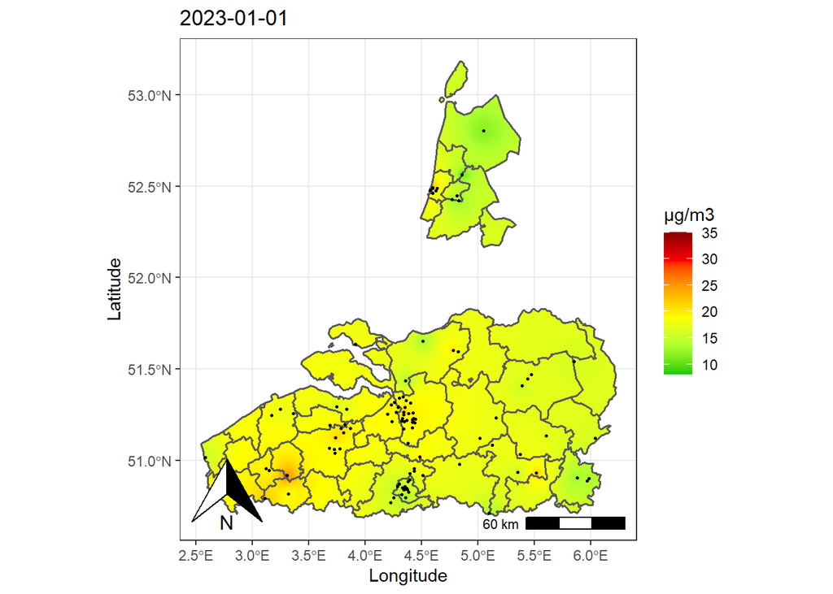

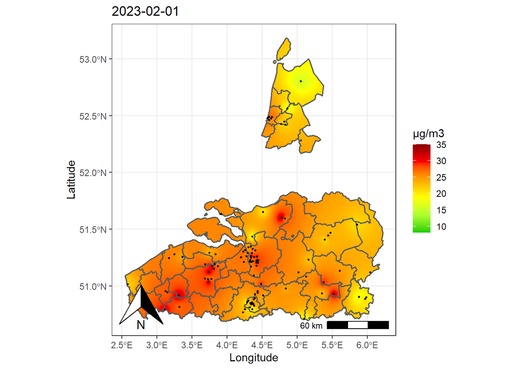

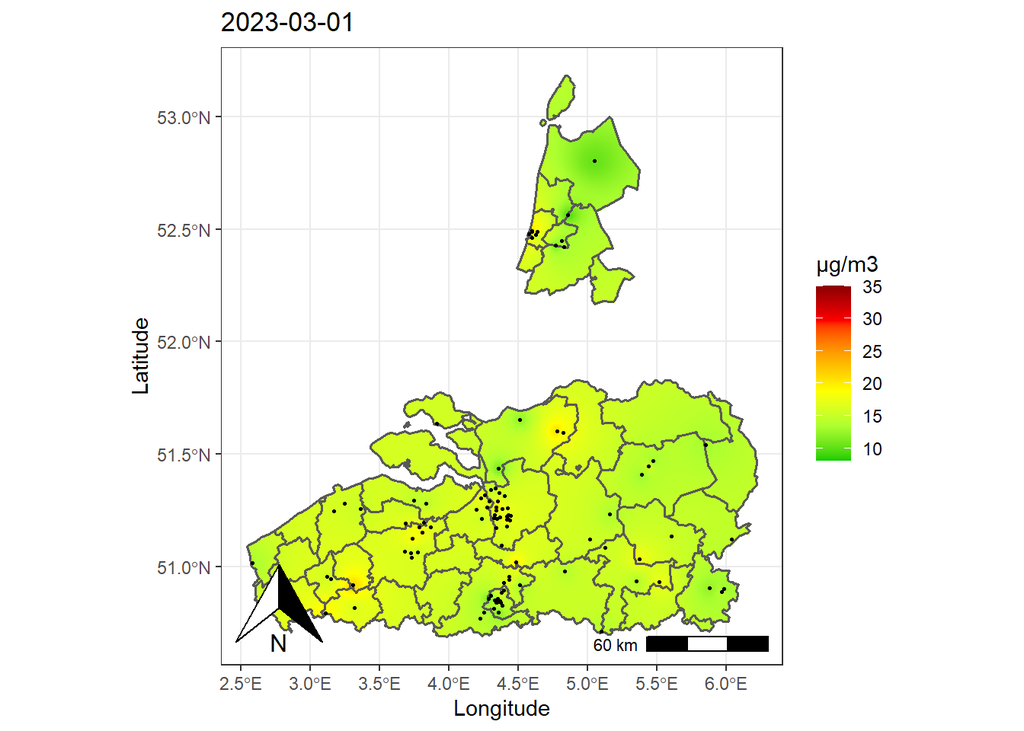

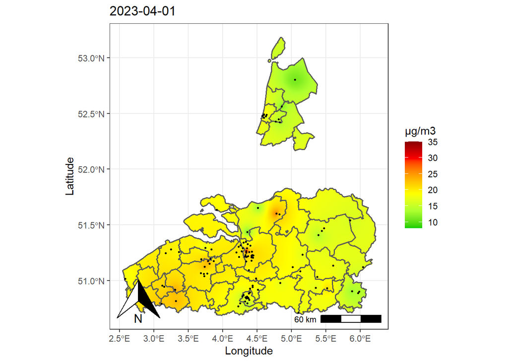

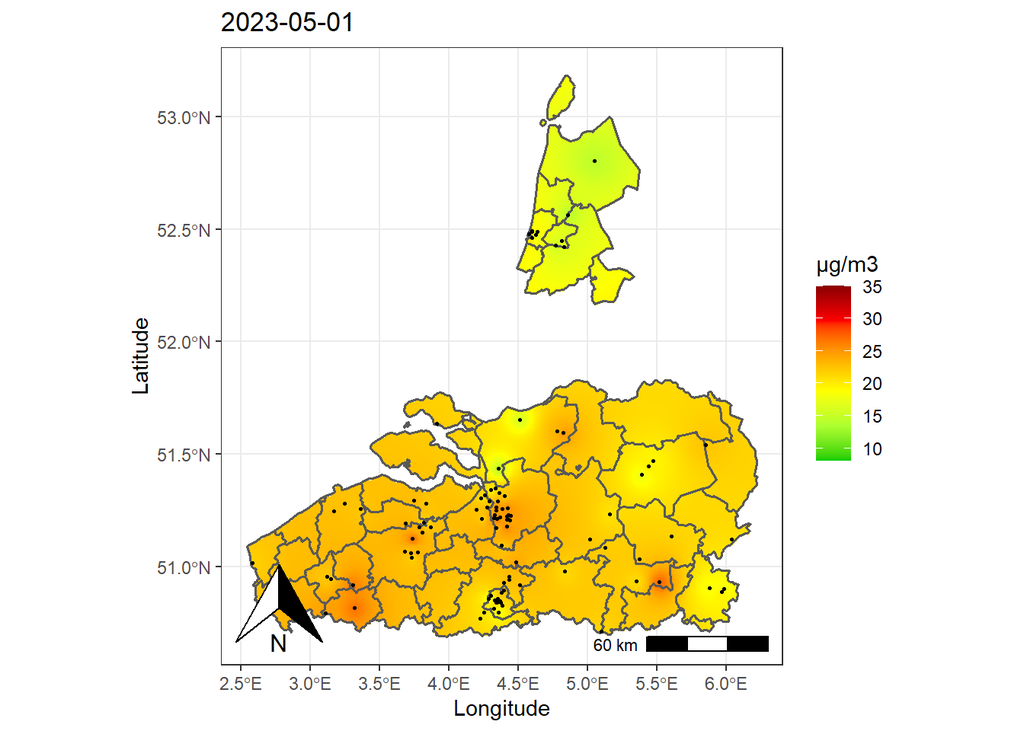

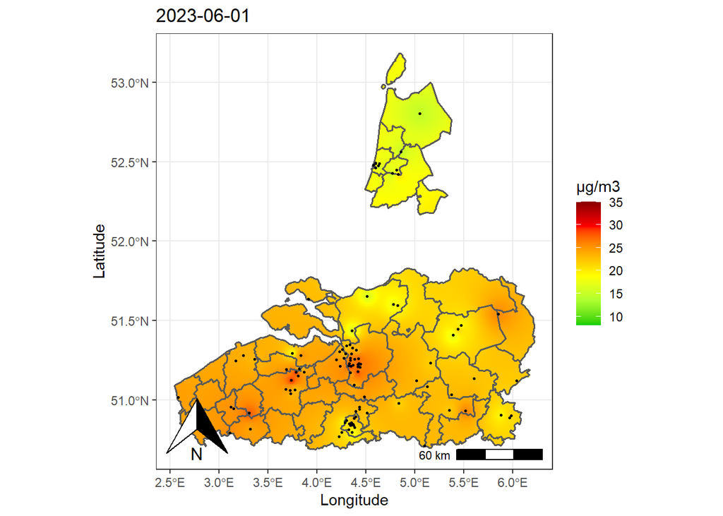

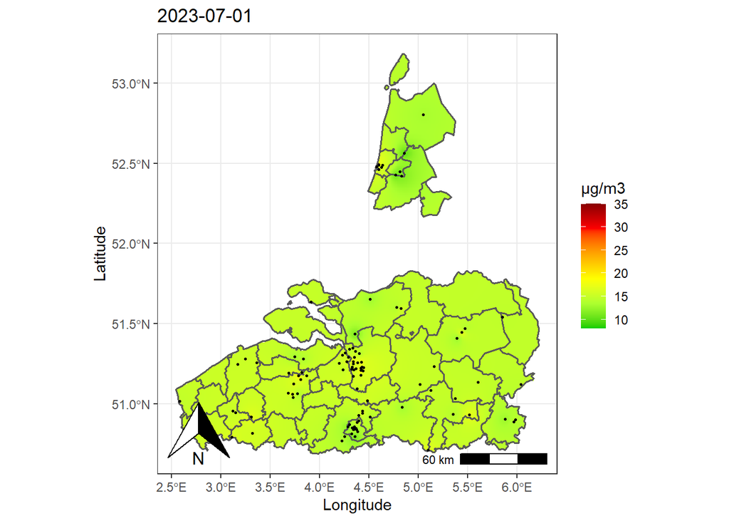

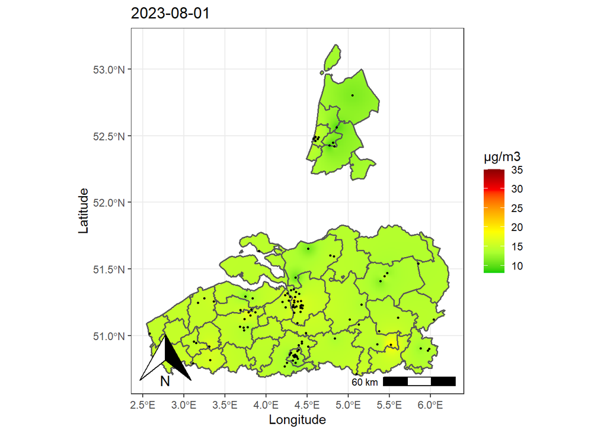

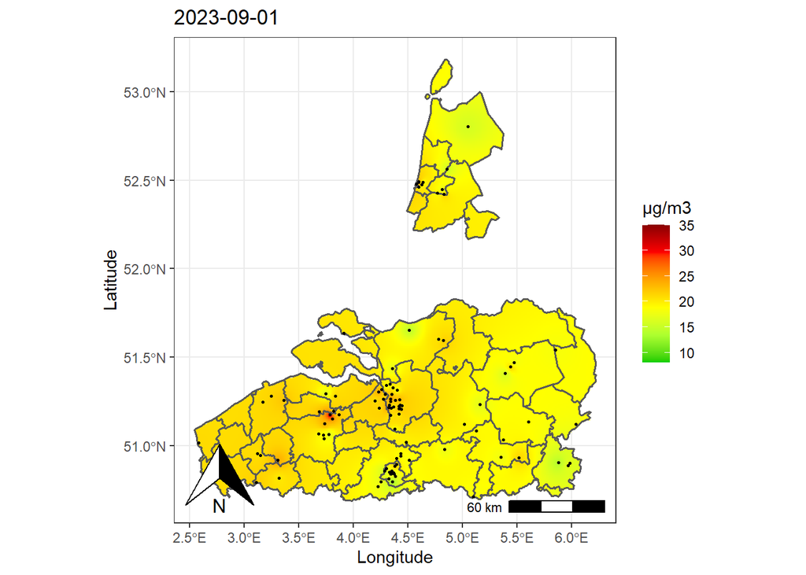

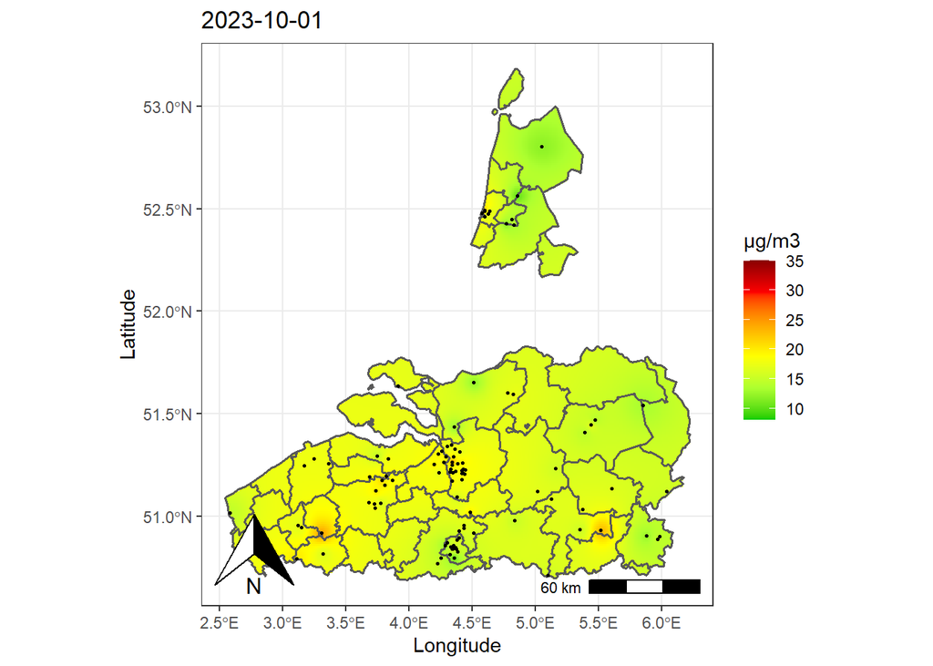

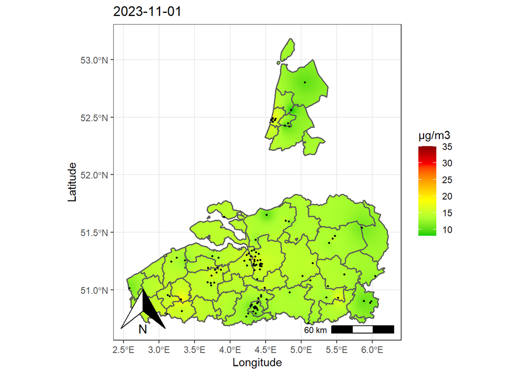

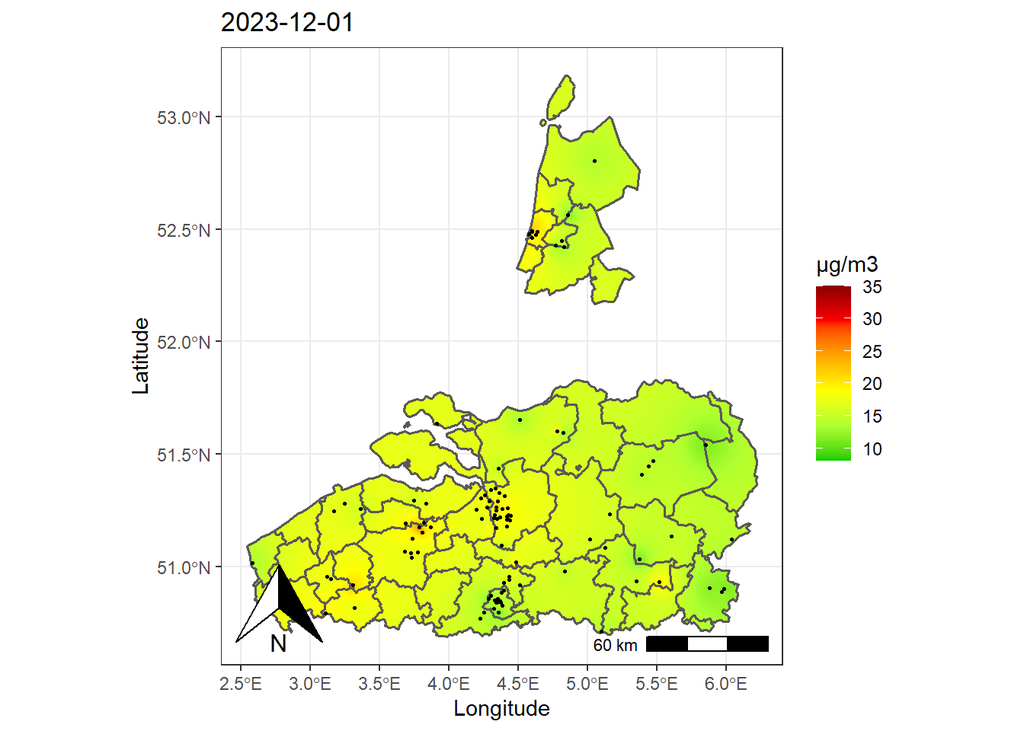

```r
EEAaq::EEAaq_idw_map(
  data = t_aggr$TimeAggr_byPollutant$PM10 %>%
    dplyr::filter(Date %in% c("2023-01-01","2023-02-01")),
  NUTS_extborder = "NUTS3",
  NUTS_intborder = "LAU",
  pollutant = "PM10",
  aggr_fun = "max",
  distinct = TRUE,
  gradient = TRUE,
  idp = 2
)
```

```
## Map initialization started at 2025-03-24 23:02:03.772827
## Map initialization ended at 2025-03-24 23:02:15.851995
## Computing IDW interpolation started at 2025-03-24 23:02:15.852211
## Computing IDW interpolation for: 2023-01-01, 1 of 2
## [inverse distance weighted interpolation]
## Computing IDW interpolation for: 2023-02-01, 2 of 2
## [inverse distance weighted interpolation]
## Computing IDW interpolation ended at 2025-03-24 23:02:35.795247
```

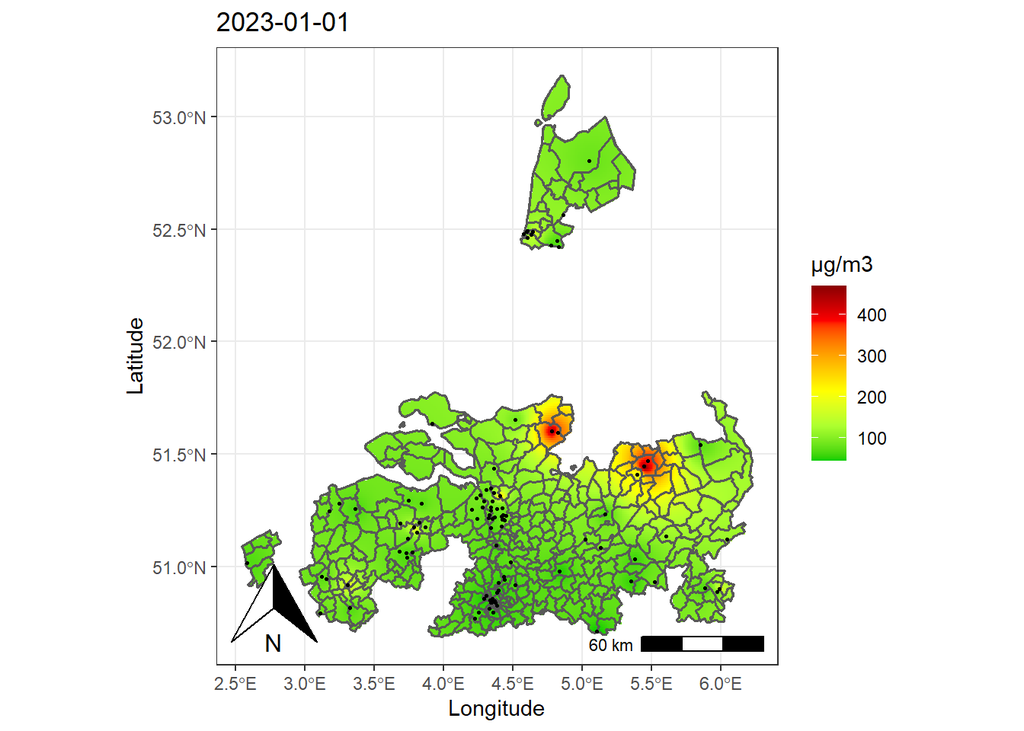

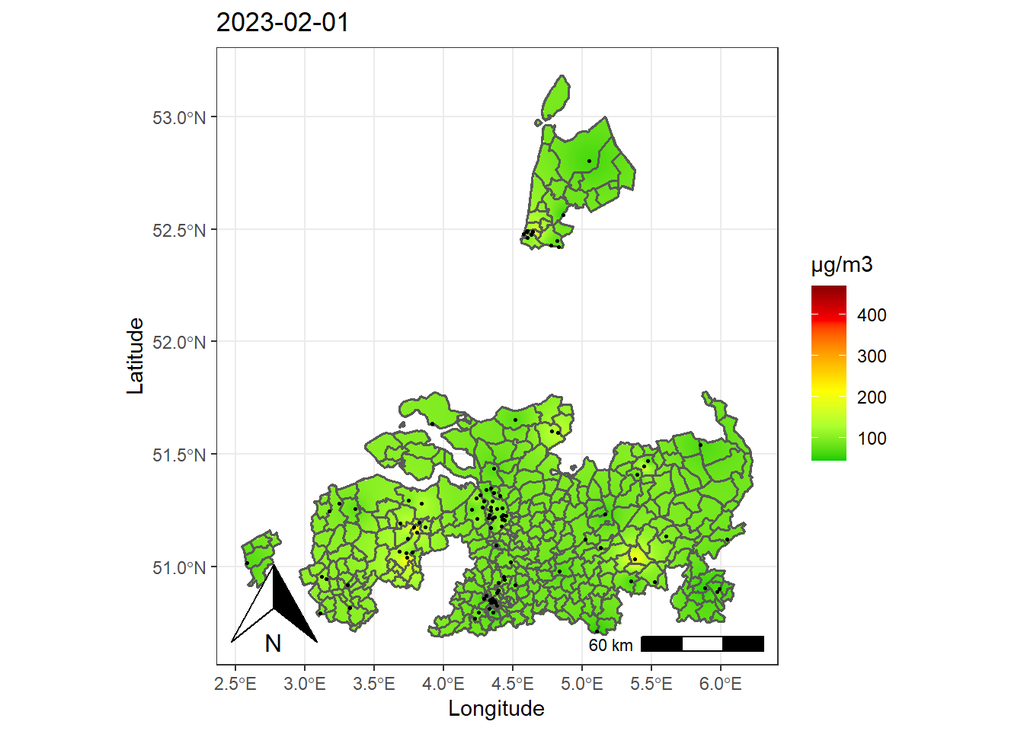